# Case Study 2: University tuition

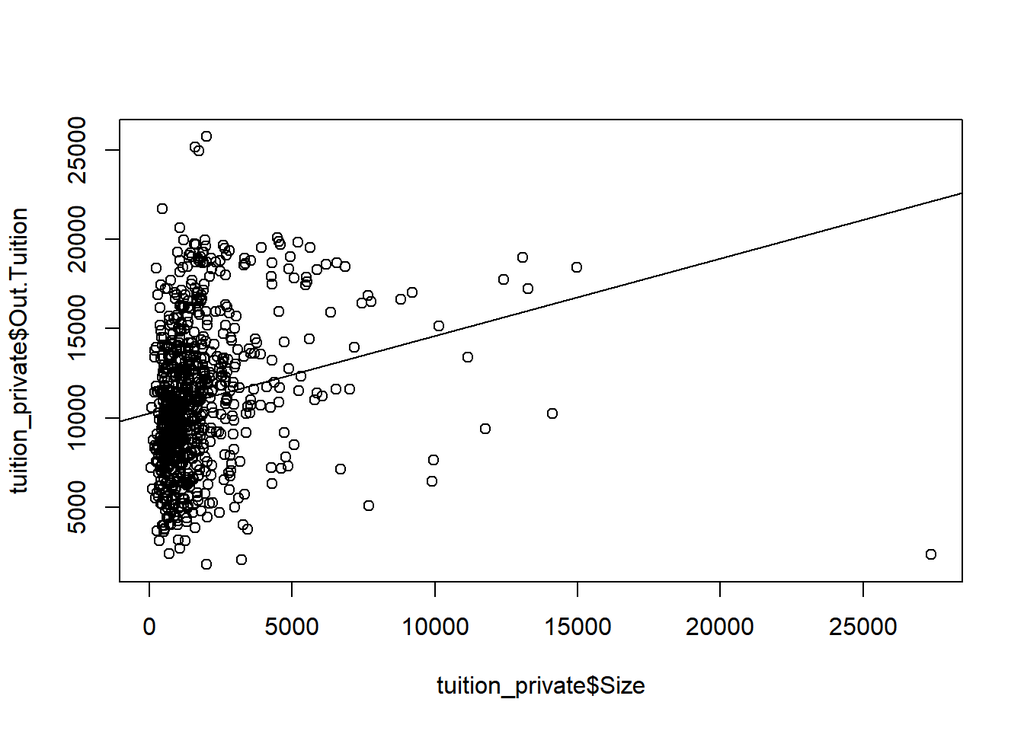

```r
  plot(tuition_private$Size, tuition_private$Out.Tuition)
  abline(sz_pr)
```

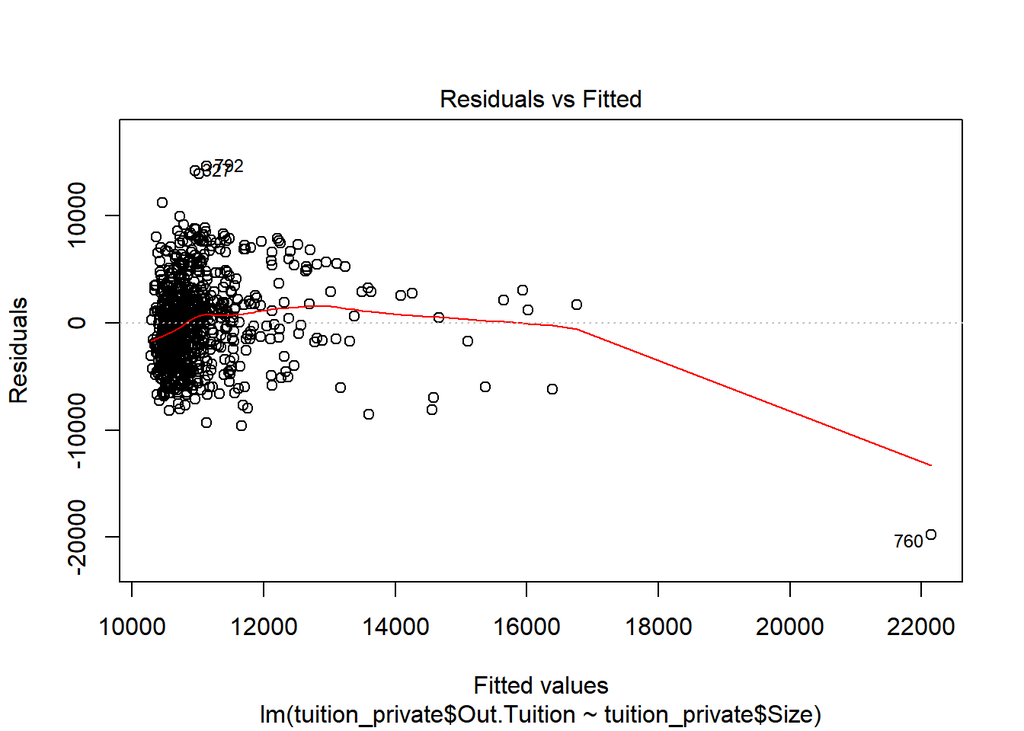

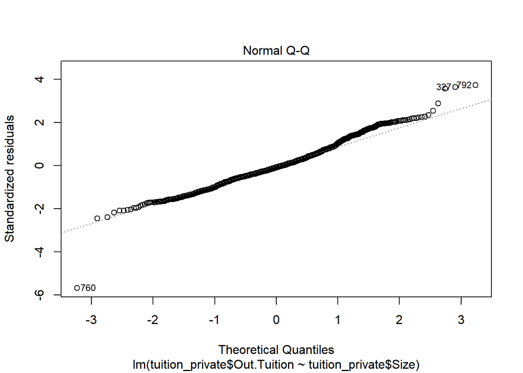

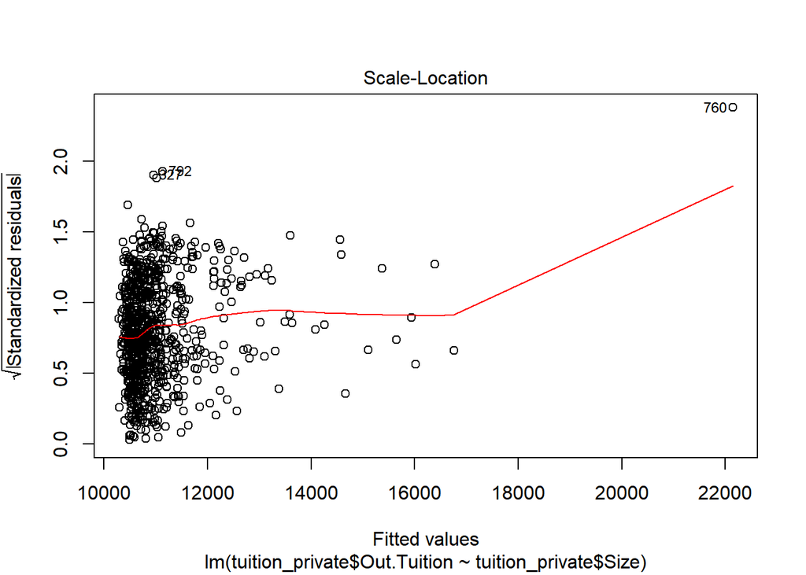

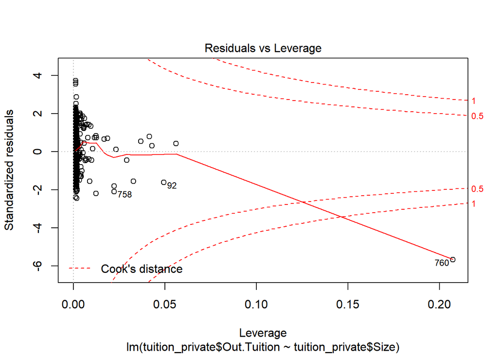

[output not shown]

```r
  plot(sz_pr)
```

## Multiple Linear Regression

We have seen that a college’s tuition relates to its size, its spending per student, and its average SAT score. We have also seen that this relationship may change based on whether the school is public or private. Ideally, instead of making separate regressions for each relationship, we could combine them all into a multiple regression. Fortunately, **R** makes this easy with `lm()`.

### Question 9:

1. Run the following code to perform a multiple regression. Interpret the results.

```r
  mult.1 <- lm(Out.Tuition ~ Size + Avg.SAT + Avg.ACT + Spending + Acc.Rate, data = tuition)
  summary(mult.1)
```

```
##
## Call:
## lm(formula = Out.Tuition ~ Size + Avg.SAT + Avg.ACT + Spending +
##     Acc.Rate, data = tuition)
##
## Residuals:
##      Min       1Q   Median       3Q      Max
## -12382.1  -1661.8   -145.9   1534.7  10590.3
##
## Coefficients:
##               Estimate Std. Error t value Pr(>|t|)
## (Intercept) -7.112e+03  1.463e+03  -4.863 1.59e-06 ***
## Size        -1.989e-01  2.343e-02  -8.488 2.87e-16 ***
## Avg.SAT      6.032e+00  2.439e+00   2.473  0.01377 *
## Avg.ACT      2.979e+02  1.040e+02   2.866  0.00435 **
## Spending     3.802e-01  2.994e-02  12.700  < 2e-16 ***
## Acc.Rate     2.193e+03  9.047e+02   2.424  0.01574 *
## ---
## Signif. codes:  0 '***' 0.001 '**' 0.01 '*' 0.05 '.' 0.1 ' ' 1
##
## Residual standard error: 2512 on 463 degrees of freedom
##   (833 observations deleted due to missingness)
## Multiple R-squared:  0.5978, Adjusted R-squared:  0.5934
## F-statistic: 137.6 on 5 and 463 DF,  p-value: < 2.2e-16
```

```
According to the output, the regression involves five variables:

There is 0.001 level significance showing that the larger the `Size`, the smaller the tuition.

There is 0.05 level significance showing that the larger the higher the `Average SAT`, the higher the tuition.

There is 0.01 level significance showing that the larger the higher the `Average ACT`, the higher the tuition.

There is 0.001 level significance showing that the higher the `Spending`, the higher the tuition.

There is 0.05 level significance showing that the higher the `Acceptance Rate`, the higher the tuition.
```

2. We can also mix and match continuous variables with categorical ones. Let’s add `Public` to the regression. The following two models are slightly different, but give essentially identical output. What is the difference between them, and why is it important even though the output still the same?

```r
  mult.2 <- lm(Out.Tuition ~ Size + Avg.SAT + Avg.ACT + Spending + Public, data = tuition)
  summary(mult.2)
```

```
##
## Call:
## lm(formula = Out.Tuition ~ Size + Avg.SAT + Avg.ACT + Spending +
##     Public, data = tuition)
##
## Residuals:
##     Min      1Q  Median      3Q     Max
## -9998.4 -1398.7    50.9  1355.7 10607.1
##
## Coefficients:
##               Estimate Std. Error t value Pr(>|t|)
## (Intercept) -9.316e+03  1.088e+03  -8.561  < 2e-16 ***
## Size        -3.002e-03  2.912e-02  -0.103 0.917941
## Avg.SAT      8.122e+00  2.210e+00   3.675 0.000265 ***
## Avg.ACT      1.193e+02  9.639e+01   1.238 0.216389
## Spending     3.075e-01  2.747e-02  11.194  < 2e-16 ***
## Public       3.380e+03  3.351e+02  10.087  < 2e-16 ***
## ---
## Signif. codes:  0 '***' 0.001 '**' 0.01 '*' 0.05 '.' 0.1 ' ' 1
##
## Residual standard error: 2288 on 466 degrees of freedom
##   (830 observations deleted due to missingness)
## Multiple R-squared:  0.6672, Adjusted R-squared:  0.6637
## F-statistic: 186.9 on 5 and 466 DF,  p-value: < 2.2e-16
```

```r
  mult.3 <- lm(Out.Tuition ~ Size + Avg.SAT + Avg.ACT + Spending + factor(Public), data = tuition)
  summary(mult.3)
```

```
##
## Call:
## lm(formula = Out.Tuition ~ Size + Avg.SAT + Avg.ACT + Spending +
##     factor(Public), data = tuition)
##
## Residuals:
##     Min      1Q  Median      3Q     Max
## -9998.4 -1398.7    50.9  1355.7 10607.1
##
## Coefficients:
##                   Estimate Std. Error t value Pr(>|t|)
## (Intercept)     -5.936e+03  1.002e+03  -5.921 6.21e-09 ***
## Size            -3.002e-03  2.912e-02  -0.103 0.917941
## Avg.SAT          8.122e+00  2.210e+00   3.675 0.000265 ***
## Avg.ACT          1.193e+02  9.639e+01   1.238 0.216389
## Spending         3.075e-01  2.747e-02  11.194  < 2e-16 ***
## factor(Public)2  3.380e+03  3.351e+02  10.087  < 2e-16 ***
## ---
## Signif. codes:  0 '***' 0.001 '**' 0.01 '*' 0.05 '.' 0.1 ' ' 1
##
## Residual standard error: 2288 on 466 degrees of freedom
##   (830 observations deleted due to missingness)
## Multiple R-squared:  0.6672, Adjusted R-squared:  0.6637
## F-statistic: 186.9 on 5 and 466 DF,  p-value: < 2.2e-16
```

```
while the 'factor(Public)' treats column 'Public' as a categorical variable, the 'public' default to be a integer variable.

When there is only two variables, the results will be the same. However, if the number of the categories is larger than two, the integer representation causes a problem, and implicitly assigns an order to the categoires.

For example, when there are three categories, the difference between #3 and #1 is twice as the difference between #2 and #1, which is not true and causes problem.
```

3. It is still important to check diagnostics in a multiple regression, although it can be harder to track down the source of problems. Use `plot( )` to look at diagnostics for `mult.3`, and comment.

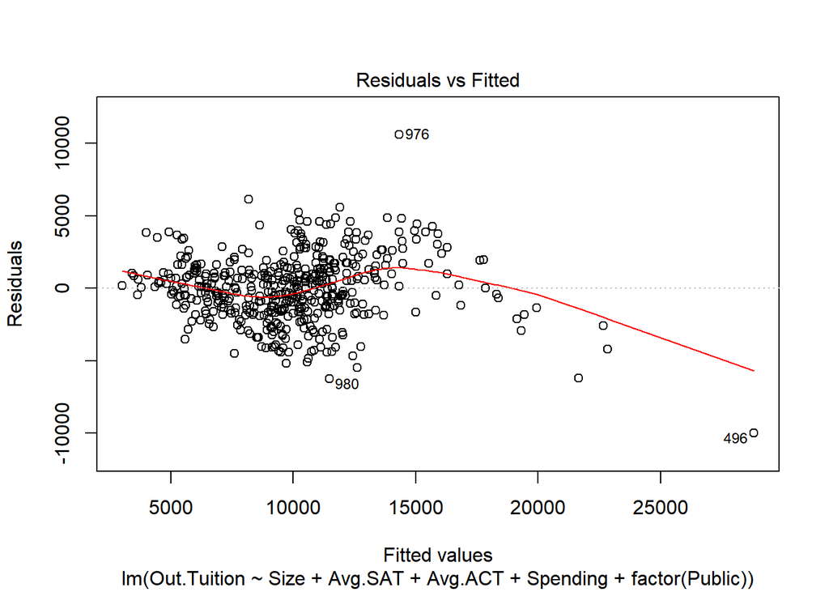

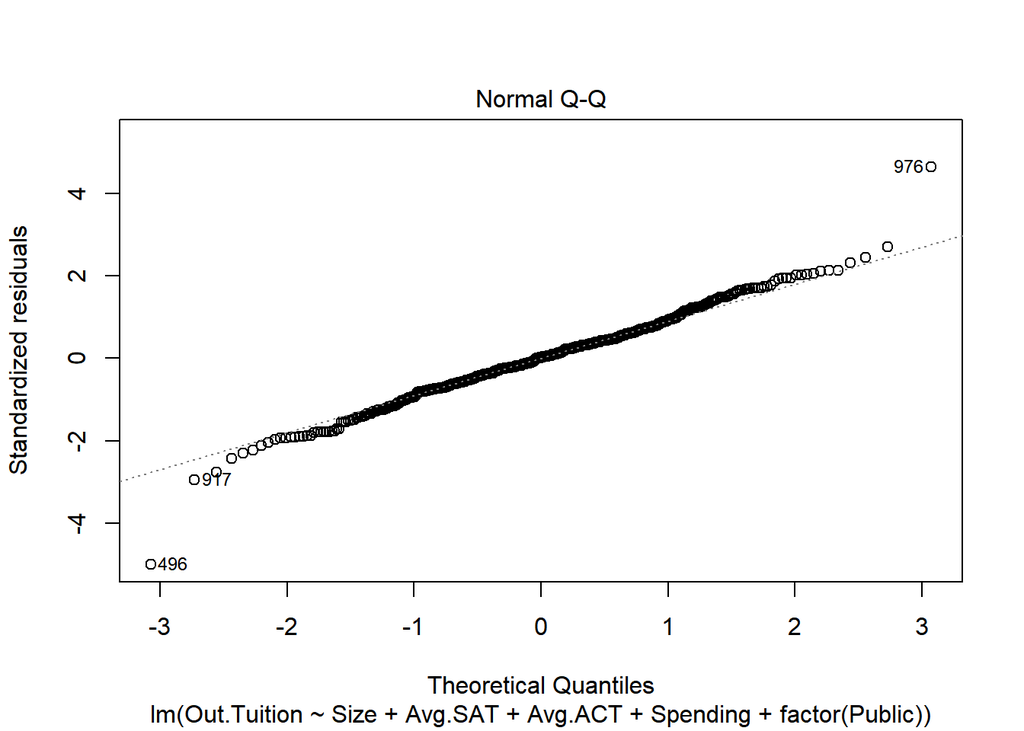

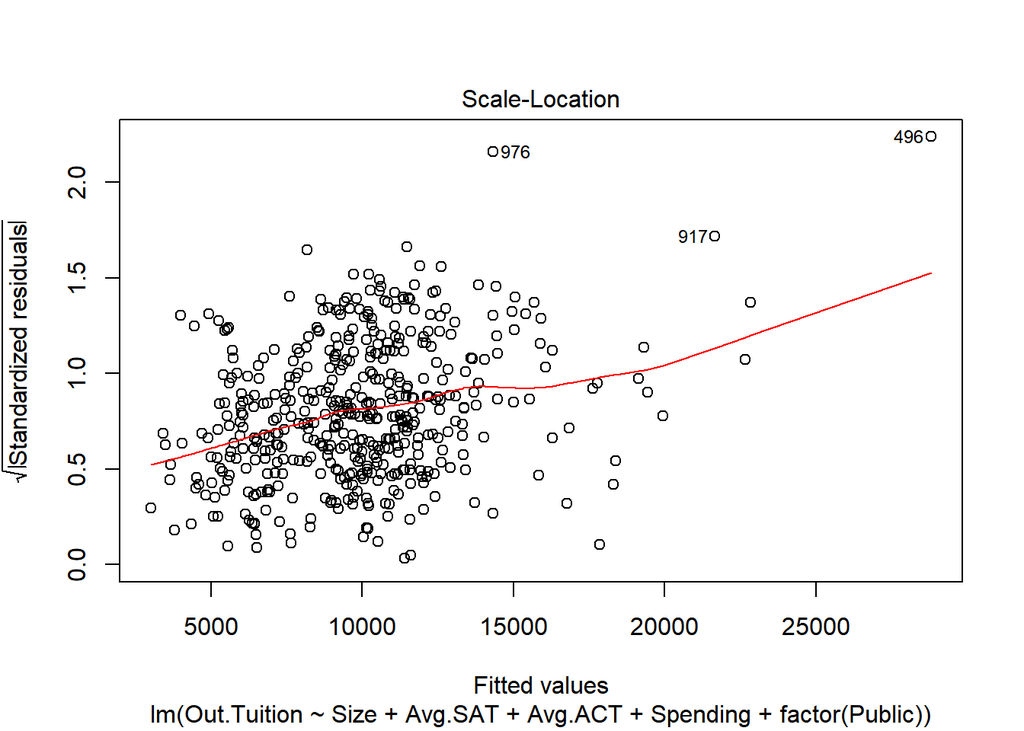

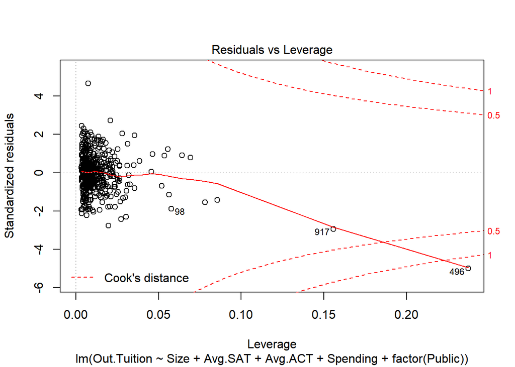

[output not shown]

```r
  plot(mult.3)
```

### Question 10:

1. A big problem in multiple regression is *collinearity*, which means that two or more explanatory variables are correlated with each other. Read the documentation for `pairs( )`, and then use it on the variables involved in `mult.3`. *Hint: You can use the option `col = tuition$Public` in `pairs( )`*

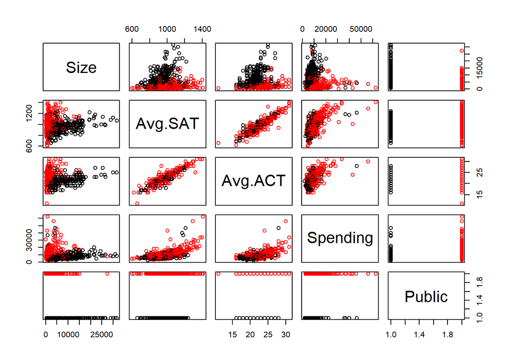

```r
  pairs(~ Size + Avg.SAT + Avg.ACT + Spending + Public, data = tuition, col = tuition$Public)
```

2. Do any of the variables seem strongly related? What is their correlation?

```r
  attach(tuition)
  print(cor(Avg.SAT, Avg.ACT, use="pairwise.complete.obs"))
```

```
## [1] 0.9067595
```

```r
  print(cor(Avg.SAT, Spending, use="pairwise.complete.obs"))
```

```
## [1] 0.6148969
```

```r
  print(cor(Avg.ACT, Spending, use="pairwise.complete.obs"))
```

```
## [1] 0.5718615
```

[output not shown]

3. Explain in your own words why the correlation between the variables you discussed in (a) could be a problem.

```
Although collinearity does not significantly change the output of predictions, there are several issues when it comes to model interpretation.

When two explanatory variables are correlated with each other, the estimated coefficient of one variable will depen on the other variable. And estimated regression coefficients will decrease.
```

## Sneak Preview: Interaction Terms

We saw in 12c that whether a school is public or private can affect not only the tuition, but also how the tuition relates to other variables. In a multiple regression, this effect can be captured through interaction terms, which are expressed by `var1:var2`, and measure how much one variable changes the effect of the other.

Read the following paragraph from the documentation `?formula` for some shortcuts for including interactions:

```
In addition to + and :, a number of other operators are useful in model formula. The * operator denotes factor crossing: a*b interpreted as a+b+a:b. The ^ operator indicates crossing to the specified degree. For example (a+b+c)^2 is identical to (a+b+c)*(a+b+c) which in turn expands to a formula containing the main effects for a, b and c together with their second-order interactions. The %in% operator indicates that the terms on its left are nested within those on the right. For example a + b %in% a expands to the formula a + a:b. The - operator removes the specified terms, so that (a+b+c)^2 - a:b is identical to a + b + c + b:c + a:c. It can also used to remove the intercept term: when fitting a linear model y ~ x - 1 specifies a line through the origin. A model with no intercept can be also specified as y ~ x + 0 or y ~ 0 + x.
```

### Question 11:

Create your own multiple regression that predicts tuition from whichever variables you choose, as well as some interaction terms between `Public` and other variables. Don’t worry about using any official methods to pick variables; simply try a few things and choose the model that seems best. Interpret the results; in particular, think very carefully about what the coefficient for an interaction term with `Public` might mean.

```r
  my_lm = lm(Out.Tuition ~ Spending + factor(Public) : Spending + Avg.ACT : Avg.SAT + Avg.ACT : Spending, data = tuition)
  summary(my_lm)
```

```
##
## Call:
## lm(formula = Out.Tuition ~ Spending + factor(Public):Spending +
##     Avg.ACT:Avg.SAT + Avg.ACT:Spending, data = tuition)
##
## Residuals:
##      Min       1Q   Median       3Q      Max
## -10638.6  -1278.1     45.5   1200.2  10164.3
##
## Coefficients:
##                            Estimate Std. Error t value Pr(>|t|)
## (Intercept)              -3.466e+03  8.900e+02  -3.895 0.000113 ***
## Spending                  1.110e+00  1.623e-01   6.836 2.55e-11 ***
## Spending:factor(Public)2  4.093e-01  2.907e-02  14.082  < 2e-16 ***
## Avg.ACT:Avg.SAT           4.448e-01  3.669e-02  12.122  < 2e-16 ***
## Spending:Avg.ACT         -4.499e-02  6.017e-03  -7.476 3.81e-13 ***
## ---
## Signif. codes:  0 '***' 0.001 '**' 0.01 '*' 0.05 '.' 0.1 ' ' 1
##
## Residual standard error: 2205 on 468 degrees of freedom
##   (829 observations deleted due to missingness)
## Multiple R-squared:  0.6895, Adjusted R-squared:  0.6868
## F-statistic: 259.8 on 4 and 468 DF,  p-value: < 2.2e-16
```

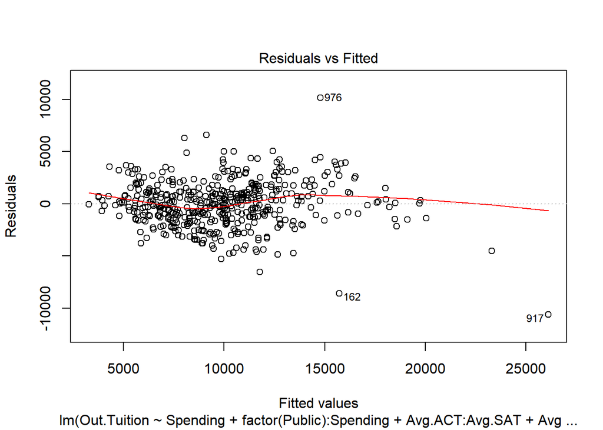

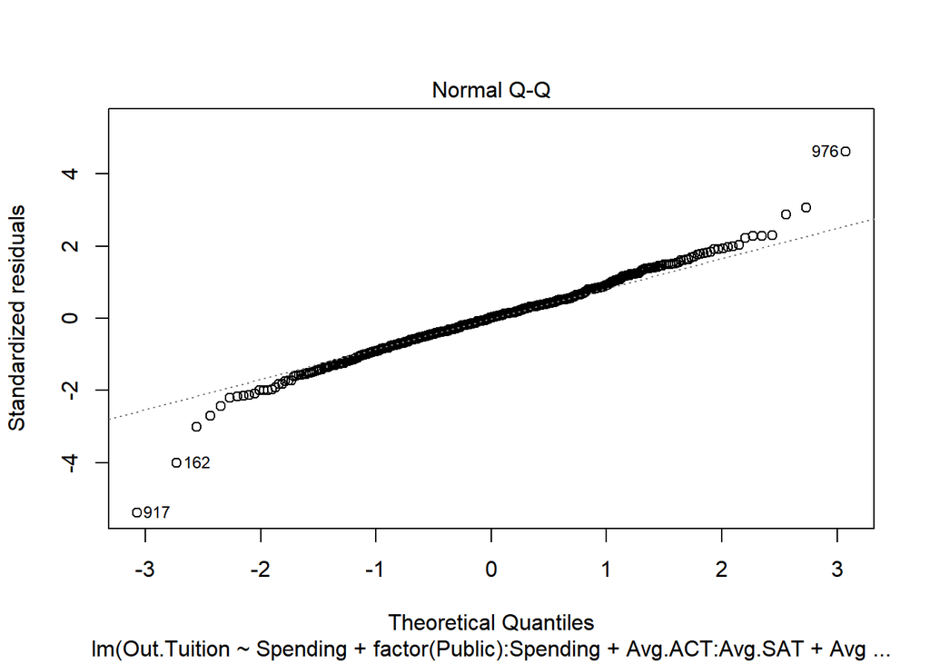

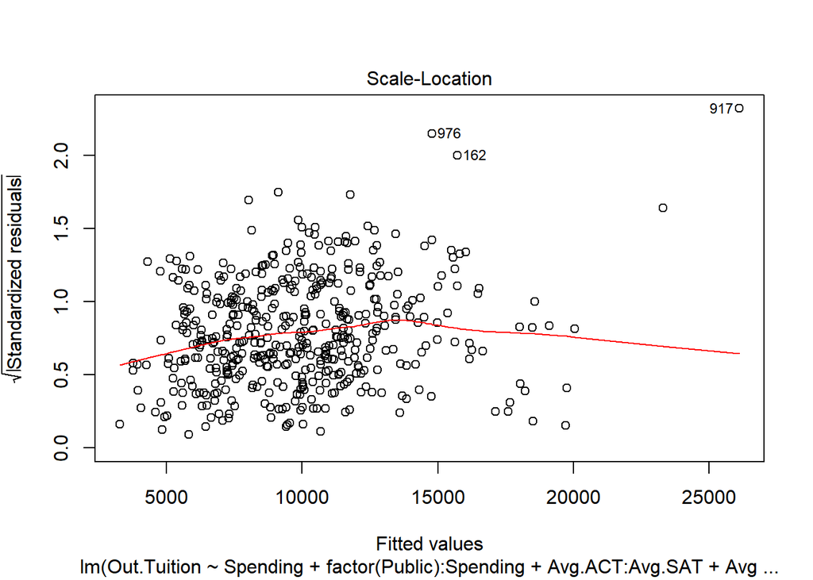

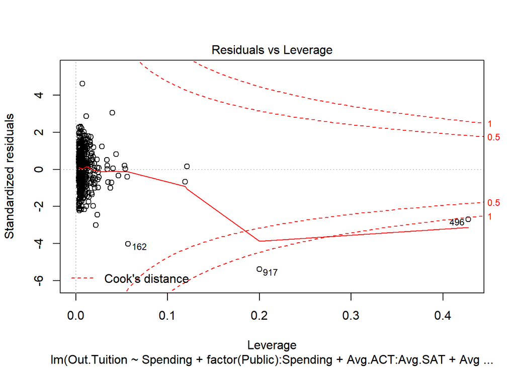

[output not shown]

```r
  plot(my_lm)
```